# Unit 2: Types of Data

# Part 4: Graphic Displays of Statistical Descriptions

## Quantile Plot

Plots every sorted value $x_i$ against its percentile position $f_i = \frac{i-0.5}{N}$

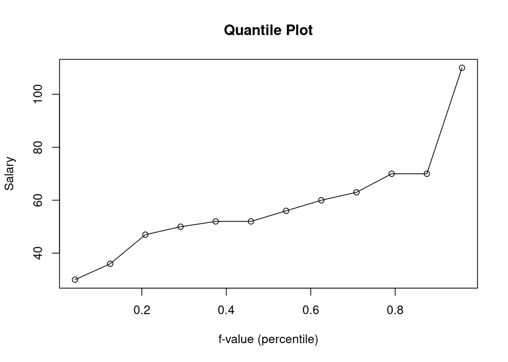

```r
salary <- sort(c(30,36,47,50,52,52,56,60,63,70,70,110))
N <- length(salary)
f <- (seq_along(salary) - 0.5) / N

plot(f, salary, type = "o", xlab = "f-value (percentile)", ylab = "Salary",
     main = "Quantile Plot")
```

**Use:** see the *entire* distribution’s shape at a glance — including $Q_1$, median, $Q_3$ directly on the curve.

## Quantile–Quantile (Q-Q) Plot

Plots the quantiles of **one** distribution against the quantiles of **another** — reveals a *shift* between two groups.

## 🏭 Industry Example — Comparing Two Store Branches / A-B Test Groups

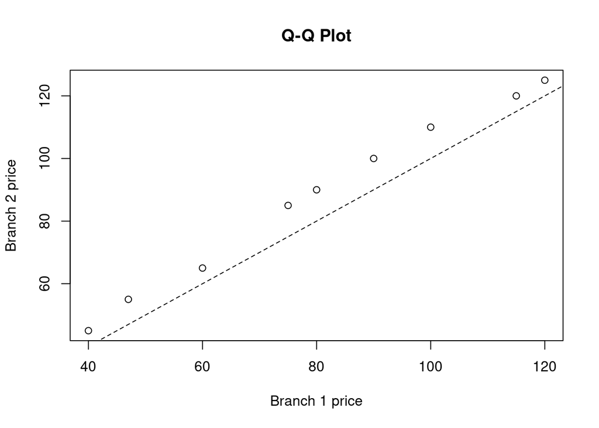

```r
branch1_prices <- sort(c(40,47,60,75,80,90,100,115,120))
branch2_prices <- sort(c(45,55,65,85,90,100,110,120,125))

# Same-length Q-Q plot: just plot corresponding sorted values against each other
plot(branch1_prices, branch2_prices,
     xlab = "Branch 1 price", ylab = "Branch 2 price",
     main = "Q-Q Plot")
abline(a = 0, b = 1, lty = 2)   # y = x reference line
```

If points sit **above** the diagonal line → Branch 2 consistently prices higher at every quantile — exactly the shift the textbook found between its two `AllElectronics` branches.

## Histograms

- For a **numeric** attribute: values are bucketed into equal-width ranges (**bins**)
- Bar height = frequency (count) in that bin

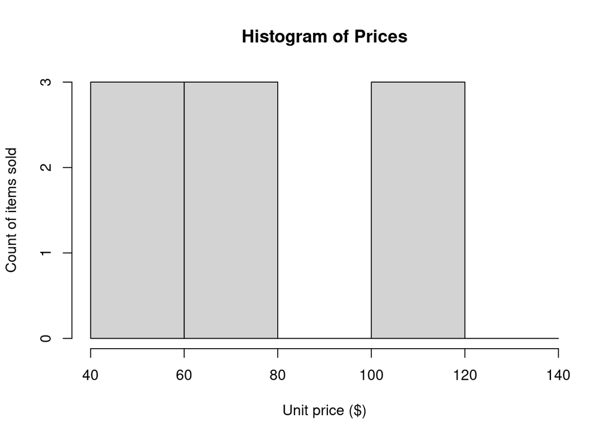

```r
prices <- c(40,43,47,74,75,78,115,117,120)
hist(prices, breaks = c(40,60,80,100,120,140),
     xlab = "Unit price ($)", ylab = "Count of items sold",
     main = "Histogram of Prices")
```

**Nominal attribute equivalent:** a **bar chart** (one bar per category, not a bucketed range) — use `barplot(table(category))`.

## 🏭 Industry Example — Histograms Everywhere in Analytics Dashboards

| Platform | Histogram of… |
| --- | --- |
| **Google Analytics / Mixpanel** | session duration, page-load time |
| **Zomato/Swiggy ops dashboard** | delivery time distribution across all orders |
| **HR analytics (Naukri/LinkedIn)** | years-of-experience distribution of applicants |
| **College placement cell** | package (LPA) distribution across all placed students |

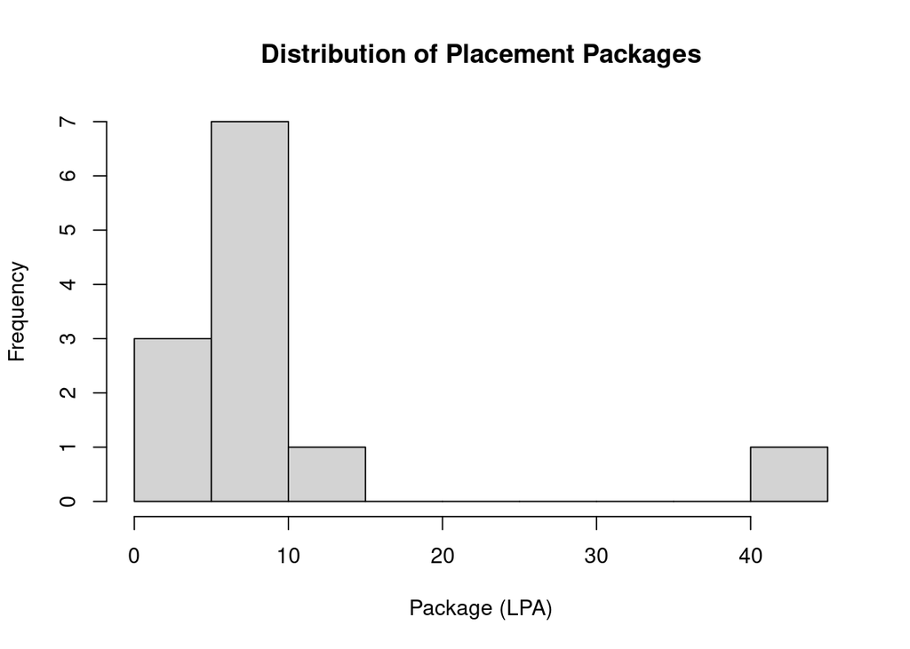

```r
df <- data.frame(package_lpa = c(4,4.5,5,6,6,6.5,7,8,8,9,12,45))  # 45 = one outlier offer
hist(df$package_lpa, breaks = 8, xlab = "Package (LPA)",
     main = "Distribution of Placement Packages")
```

```r
# One glance shows: most offers cluster 4-9 LPA, with a rare high outlier
```

## Scatter Plots & Correlation

Plots **two** numeric attributes as (x, y) points — reveals relationships between them.

```
Positive correlation:   points slope ↗ (lower-left to upper-right)
Negative correlation:   points slope ↘ (upper-left to lower-right)
No correlation:         no visible pattern
```

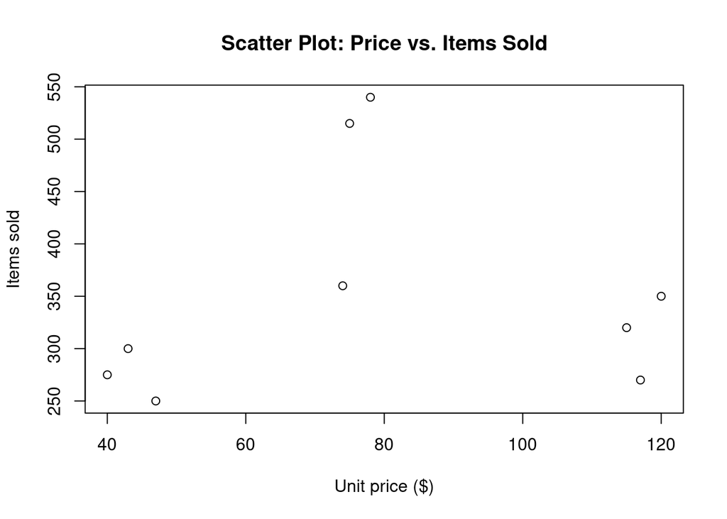

```r
price <- c(40,43,47,74,75,78,115,117,120)
items_sold <- c(275,300,250,360,515,540,320,270,350)
plot(price, items_sold, xlab = "Unit price ($)", ylab = "Items sold",
     main = "Scatter Plot: Price vs. Items Sold")
```

## 🏭 Industry Example — Correlation Analysis in Business Decisions

| Domain | Scatter plot pair | Typical finding |
| --- | --- | --- |
| **Marketing** | ad spend vs. sales revenue | positive correlation |
| **E-commerce** | delivery time vs. customer rating | negative correlation |
| **EdTech** | hours studied on app vs. exam score | positive correlation |
| **Real estate** | distance-from-city-center vs. price/sq.ft | negative correlation |
| **HR analytics** | commute distance vs. employee attrition | often positive correlation |

```r
# Quick correlation coefficient (Pearson's r) alongside the scatter plot
hours_studied <- c(1,2,3,4,5,6,7,8)
exam_score    <- c(40,45,55,58,65,70,80,88)
cor(hours_studied, exam_score)   # → ~0.99 (strong positive)
```

```
## [1] 0.9944405
```

⚠️ **Always repeat to students: correlation ≠ causation** (studying *correlates* with better scores — but confounders like motivation could explain both).

## 🎯 Practical Example — Reading All Four Plots Together

**Scenario:** analyzing a `student_performance.csv` dataset.

| Plot | What you’d check |
| --- | --- |
| Histogram of `attendance_pct` | Is attendance mostly high, or bimodal (regular vs. irregular students)? |
| Boxplot of `cgpa` by `branch` | Which branch has the widest spread / most outliers? |
| Scatter of `attendance_pct` vs `cgpa` | Is there a positive correlation worth modeling? |
| Quantile plot of `package_lpa` | Is placement package heavily right-skewed (a few huge offers)? |

**This is exactly the EDA step from your Data Science course — same ideas, same tools.**